# Convex [Clustering and Biclustering](https://en.wikipedia.org/wiki/Cluster_analysis) with application in R

Marta Karas

30 Sep 2016

# My story with `R` in USA

- `R` skill brought me to work in USA in Biostatistics Departments
- Top #1 tool used in academic Biostatsistics
- Reproducibility & usability awareness - rarely one can see a methodology paper published without corresponding `R` package

# Clustering

# Cluster analysis - goals

- We perform clustering when we want to group or segment the data set into subsets so that objects within each subset are more closely related to others than those objects assigned to other subsets.

# Motivation: cancer subtype discovery

- A cancer may present clinically as a homogenous disease, but it typically consists of several distinct subtypes at the molecular level
- One of cancer research goals is to identify such cancer subtypes - groups of patients that share distinct genomic signatures and cancer-differing clinical outcomes
- It is the first step towards developing personalized treatment strategies (example: see MD Anderson Cancer Center (Houston, TX) [Personalized Cancer Therapy webpage](https://pct.mdanderson.org/#/) based on Molecular Profiling)

# Cancer subtype discovery as a biclustering problem

- We look for subtypes of cancerous tumors that have similar molecular profiles and the genes that characterize each of the them
- This subtype discovery problem can be posed as a biclustering problem of gene expression data matrix, where data is partitioned into a checkerboard-like pattern

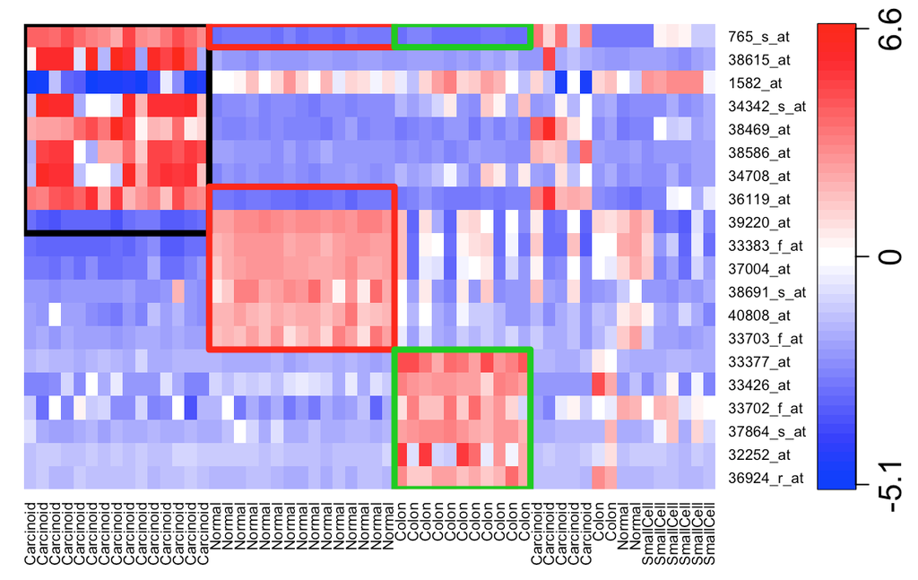

# Cancer subtype discovery as a biclustering problem - successess and failures

- Biclustering breast cancer data has identified sets of genes whose expression levels segregated patients into five subtypes with distinct survival outcomes (Sørlie et al., 2001)
- These subtypes have been reproduced in numerous other studies (Sørlie et al., 2003)
- … but some other subtypes discoveries were not (i.e. with ovarian cancer (Tothill et al., 2008))

# Cancer subtype discovery as a biclustering problem - challenges

- The failure to reproduce these other results may reflect an absence of biologically meaningful groupings
- … but another possibility may be related to limitations in the computational methods currently used to identify biclusters
- **Goal**: Discover clinically meaningful & reproducible cancer subtypes

# Simple solution: bicluster heatmap with `hclust`

# Simple solution: bicluster heatmap with `hclust`

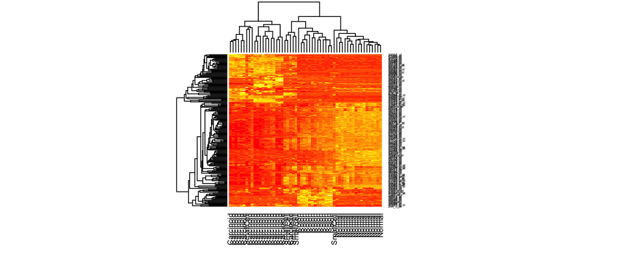

```r
library(s4vd)
data(lung200) # lung cancer data set (Bhattacharjee et al. 2001)

lung200.D.mat <- dist(lung200, method = "euclidean")
lung200.hclust <- hclust(t(lung200.D.mat), method = "average")

heatmap(lung200, Rowv = as.dendrogram(lung200.hclust), cexRow = 0.3, cexCol = 0.7)
```

# Simple solution: `hclust` - algorithm

1. Begin with $n$ observations and a measure (i.e. Euclidean distance) of all the $n = n(n − 1)/2$ pairwise dissimilarities. Treat each observation as its own cluster.
2. For $i=n,n−1,...,2$:
   - Examine all pairwise inter-cluster dissimilarities among the $i$ clusters and identify the pair of clusters that are least dissimilar (that is, most similar). Fuse these two clusters.
   - Compute the new pairwise inter-cluster dissimilarities among the $i-1$ remaining clusters.

# Simple solution: `hclust` - pros and cons

- Pros:
  - Easy to interpret
  - Fast computation
- Cons:
  - Lack of global objective function
  - Instability (subject to perturbations in data, distance choice, linkage type choice)
  - How to choose number of biclusters?

# `hclust` - distance choice effect

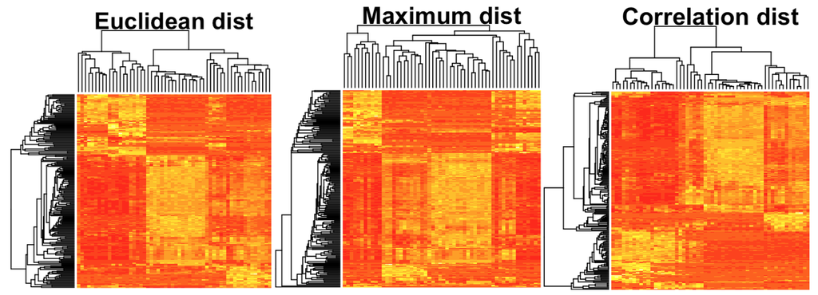

```r
# Function to plot heatmap with hclust dendrogram (method = "average")
plot.lung200.heatmap.1 <- function(row.dist, col.dist, plt.title){
  heatmap(lung200, main = plt.title,
          cexRow = 0.3, cexCol = 0.7, labRow = FALSE, labCol = FALSE,
          Rowv = as.dendrogram(hclust(row.dist, method = "average")),
          Colv = as.dendrogram(hclust(col.dist, method = "average")))
}


D.mat.row <- dist(lung200, method = "euclidean")
D.mat.col <- dist(t(lung200), method = "euclidean")
plot.lung200.heatmap.1(D.mat.row, D.mat.col, "Euclidean dist")

D.mat.row <- dist(lung200, method = "maximum")
D.mat.col <- dist(t(lung200), method = "maximum")
plot.lung200.heatmap.1(D.mat.row, D.mat.col, "Maximum dist")

D.mat.row <-  as.dist(1 - cor(t(lung200)))
D.mat.col <- as.dist(1 - cor(lung200))
plot.lung200.heatmap.1(D.mat.row, D.mat.col, "Correlation dist")
```

# `hclust` - linkage function choice effect

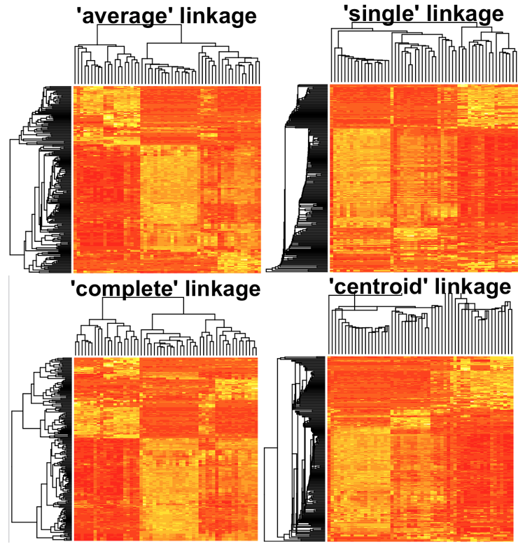

```r
# Function to plot heatmap with hclust dendrogram (distance method = "euclidean")
plot.lung200.heatmap.2 <- function(hclust.method, plt.title){
  D.mat.row <- dist(lung200, method = "euclidean")
  D.mat.col <- dist(t(lung200), method = "euclidean")
  heatmap(lung200, main = plt.title,
          cexRow = 0.3, cexCol = 0.7, labRow = FALSE, labCol = FALSE,
          Rowv = as.dendrogram(hclust(D.mat.row, method = hclust.method)),
          Colv = as.dendrogram(hclust(D.mat.col, method = hclust.method)))
}

plot.lung200.heatmap.2("average", "'average' linkage")
plot.lung200.heatmap.2("single", "'single' linkage")
plot.lung200.heatmap.2("complete", "'complete' linkage")
plot.lung200.heatmap.2("centroid", "'centroid' linkage")
```

# `hclust` - perturbations in data effect

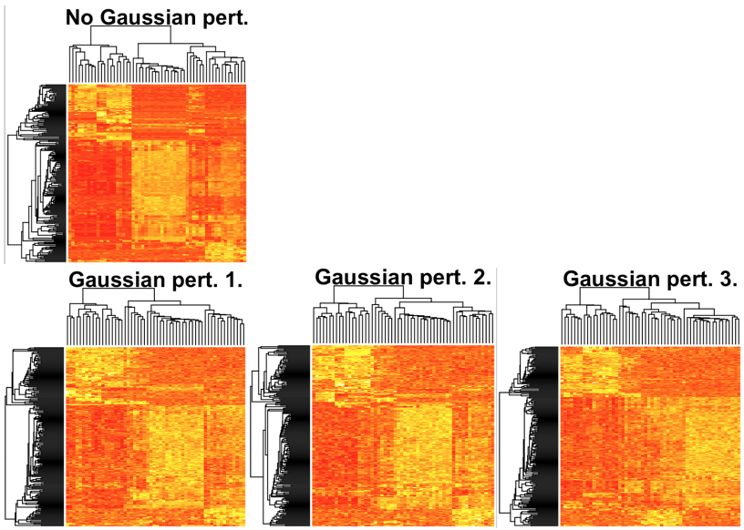

```r
plot.lung200.heatmap.3 <- function(gaussian.sd, plt.title){
  n <- dim(lung200)[1] * dim(lung200)[2]
  gaussian.err <-  matrix(rnorm(n, sd = gaussian.sd),
                          nrow = dim(lung200)[1], ncol = dim(lung200)[2])
  lung200.pert <- lung200 + gaussian.err
  D.mat.row <- dist(lung200.pert, method = "euclidean")
  D.mat.col <- dist(t(lung200.pert), method = "euclidean")
  heatmap(lung200.pert, main = plt.title,
          cexRow = 0.3, cexCol = 0.7, labRow = FALSE, labCol = FALSE,
          Rowv = as.dendrogram(hclust(D.mat.row, method = "average")),
          Colv = as.dendrogram(hclust(D.mat.col, method = "average")))
}

R2 <- 0.8
err.sd <- sqrt(var(as.vector(lung200)) * (1 - R2) / R2)
set.seed(1)
plot.lung200.heatmap.3(0, "No Gaussian pert.")
plot.lung200.heatmap.3(err.sd, "Gaussian pert. 1.")
plot.lung200.heatmap.3(err.sd, "Gaussian pert. 2.")
plot.lung200.heatmap.3(err.sd, "Gaussian pert. 3.")
```

# Question:

### Can we formulate a convex method for clustering that will yield a unique & global solution?

# Convex Biclustering

# Convex Clustering - idea

#### Goal:

- Simple and interpretable like cluster dendrogram
- Good algorithmic behavior:
  - Global minimizer
  - Stability with respect to data and other inputs
- Good, data-driven way to select cluster number and extent

#### Solution:

- Solve combinatorially hard problem with its convex surrogate:
  - All local minima are global minima
  - Algorithms converge to global minimizer regardless of initialization

# Convex Clustering - formula

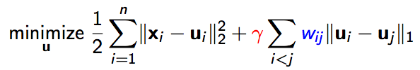

- $\mathbf{u}_i$ is a *centroid* to each data point $\mathbf{x}_i$
- $\gamma \sum_{i<j}w_{ij}|| \textbf{u}_i- \textbf{u}_j||_1$ penalty shrinks centroids together
- $\gamma$ controls BOTH cluster assignments & number of clusters:
  - $\gamma=0$ - each observation is its own cluster
  - $\gamma$ larger - column means begin to merge together into clusters
  - $\gamma$ very large - all observations fused into one cluster
- $w_{ij}$ - weights - sparse, proportional to distance between observations; pre-assigned

# Convex Clustering - solution path

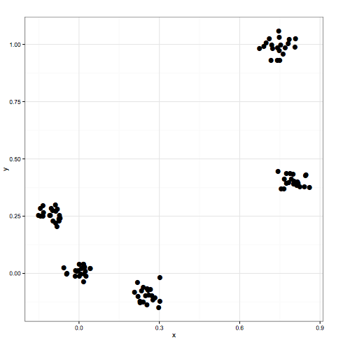

$\gamma_0 = 0$ used, gives as many clusters as points

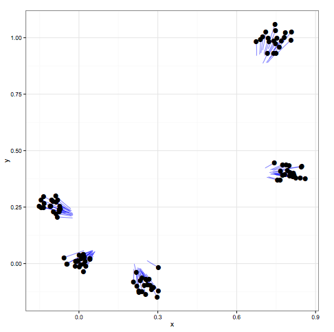

$\gamma_{k_1}$ used, such as: $\gamma_{k_1} > \gamma_0$

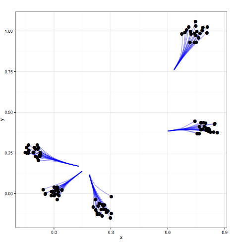

$\gamma_{k_2}$ used, such as: $\gamma_{k_2} > \gamma_{k_1}$; 5 clusters

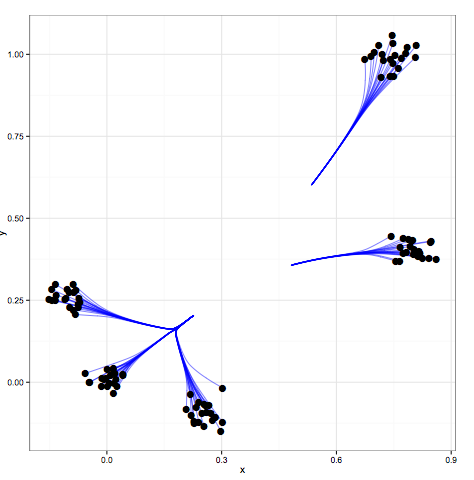

$\gamma_{k_3}$ used, such as: $\gamma_{k_3} > \gamma_{k_2}$; 3 clusters

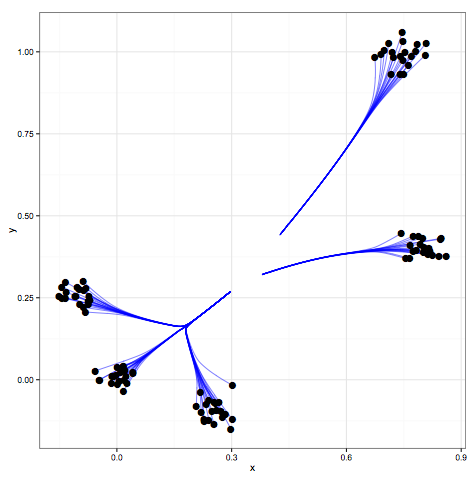

$\gamma_{k_4}$ used, such as: $\gamma_{k_4} > \gamma_{k_3}$; 3 clusters

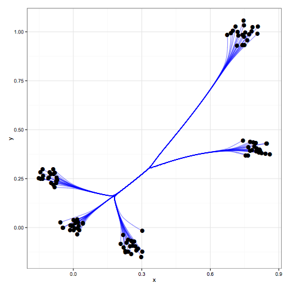

$\gamma_{k_5}$ used, such as: $\gamma_{k_5} > \gamma_{k_4}$; 1 cluster

# Convex Biclustering - formula

- Similar idea applies when we cluster both columns and rows (biclustering):

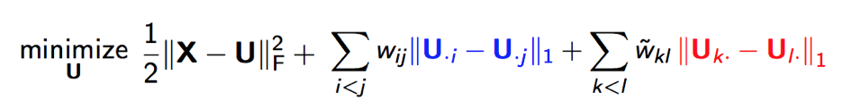

- $i$-th and $j$-th columns belong to same *column cluster* if
  $$\mathbf{U}_{\cdot i} − \mathbf{U}_{\cdot j} = 0$$
- $k$-th and $l$-th rows belong to same *row cluster* if
  $$\mathbf{U}_{k \cdot} − \mathbf{U}_{l \cdot} = 0$$

# Convex Biclustering - application on `lung200` data

# `lung200` data set

- The data consists of the expression levels of 200 genes across 56 individuals, a subset of the data studied in Lee et al. (2010).
- Subjects belong to one of four lung cancer subgroups: Normal, Carcinoid, Colon, or Small Cell.

```r
lung200[1:5, 1:5]  # lung cancer data set
```

```
##            Carcinoid Carcinoid  Carcinoid Carcinoid   Carcinoid
## 40808_at    3.945499  3.798840  4.6410622  4.866513  4.34580553
## 36924_r_at  4.453260  4.287104  4.2031069  4.764685  4.15189982
## 32252_at    1.081860  5.731959  5.7501960  5.797660 -0.05565615
## 37864_s_at -4.963623 -4.730377 -0.6692398 -2.775429 -3.01534195
## 38691_s_at -2.745149 -3.118464 -3.2292698 -2.875352 -2.81904103
```

```r
# Normalize data
X <- lung200
X <- X - mean(X)
X <- X/norm(X,'f')


# Create annotation for heatmap
types <- colnames(lung200)
ty <- as.numeric(factor(types))
cols <- rainbow(4)
YlGnBu5 <- c('#ffffd9','#c7e9b4','#41b6c4','#225ea8','#081d58')
hmcols <- colorRampPalette(YlGnBu5)(256)


# Construct weights and edge-incidence matrices
library(cvxbiclustr)
wts <- gkn_weights(X) # combines Gaussian kernel weights with k-nearest neighbor weights
w_row <- wts$w_row  # Vector of weights for row graph
w_col <- wts$w_col  # Vector of weights for column graph
E_row <- wts$E_row  # Edge-incidence matrix for row graph
E_col <- wts$E_col  # Edge-incidence matrix for column graph
```